# Coral Thermal Tolerance Genes Analysis

sangeranalyseR tutorial

```r
suppressMessages(library("sangeranalyseR"))
```

Loading the read:

```r
COI_37.seq.filepath = "~/OneDrive - UC Davis/Summer 2019/coral_thermotolerance/Data/1637633/COI_37_LAH002_Plate_PCR_00001457_H04.ab1"
COI_37.abif = read.abif(COI_37.seq.filepath)
COI_37.seq.sanger = sangerseq(COI_37.abif)
```

Trim the reads:

```r
trims = trim.mott(COI_37.abif)
trims
```

```
$start
[1] 173

$finish
[1] 515
```

Compare untrimmed with trimmed reads:

```r
seq.untrimmed = COI_37.abif@data$PBAS.2
seq.trimmed = substring(seq.untrimmed, trims$start, trims$finish)
seq.untrimmed
```

```
[1] "NNNNNNNNNNNNNNNNNNNNNNNNNNNNNTNNGNNGATCATCAAANATAGTGGTATTAAA…"
```

```r
seq.trimmed
```

```
[1] "GTCATCCCAGGAGCCCGCATGTTAAATATAGTTGTTATAAAATTCATTGCACCCAAAATA…"
```

```r
trims = trim.mott(COI_37.abif, cutoff = 0.01)
trims
```

View summary data:

```r
sa = summarise.abi.file(COI_37.abif)
sa$summary
```

Summary for a whole folder:

```r
sf = summarise.abi.folder("~/OneDrive - UC Davis/Summer 2019/coral_thermotolerance/Data/1637633/")
sf$summaries
```

One way to merge reads:

```r
fwd_COI_86 = readsangerseq("~/OneDrive - UC Davis/Summer 2019/coral_thermotolerance/Data/1637633/COI_86_LAH001_Plate_PCR_00001457_F10.ab1")
rev_COI_86 = readsangerseq("~/OneDrive - UC Davis/Summer 2019/coral_thermotolerance/Data/1637633/COI_86_LAH002_Plate_PCR_00001457_F10.ab1")

fwd_COI_86 = primarySeq(fwd_COI_86)
rev_COI_86 = primarySeq(rev_COI_86)
rev_comp_COI_86 = reverseComplement(rev_COI_86)

reads = DNAStringSet(c(as.character(fwd_COI_86), as.character(rev_comp_COI_86)))
names(reads) = c('fwd', 'rev')

merged.reads = merge.reads(reads)
names(merged.reads)
merged.reads


BrowseSeqs(merged.reads$alignment)
merged.reads$secondary.peak.columns
```

To see data frame of differences between each read and the consensus as well as the characters in each read that did not contribute to the consensus:

```r
merged.reads$differences
```

Resolving possible frameshifts with a reference amino acid sequence from GenBank (AYJ31766.1)

```r
ref.seq = "GTLYFLFGIWSGLLGRSFSFLIRTELSQPGSFLGNDQLYNTIVTRHGFIIIFFFVMPIIIGGFGNWLIPL
ILRAPDIAFPRINNIRFWLLPPSLLLLLTSSLIESGTGTGWTLYPPLSDRLAHRRKRVDLTIFSLHLAGA
SSILGAINFITTMINLRSKGMKIDHISLLCWSILLTAILLLLSLPVLAGAITILLTDRNLNTSFFDVSGG
GDPILMQGLF"

# Choose genetic code from this table:
GENETIC_CODE_TABLE

# Invert mitochondrial genetic code
inv.mito.code = getGeneticCode('SGC4', full.search = T)

merged.reads = merge.reads(reads, ref.aa.seq = ref.seq, genetic.code = inv.mito.code)
BrowseSeqs(merged.reads$alignment)
```

Readset building with regex.

```r
fwd_COI_reads = "_LAH001_Plate_PCR_00001457_[[:upper:]]\\d\\d.ab1"
rev_COI_reads = "_LAH002_Plate_PCR_00001457_[[:upper:]]\\d\\d.ab1"
input.folder = "~/OneDrive - UC Davis/Summer 2019/coral_thermotolerance/Data/abif//"
rs = make.readsets(input.folder, fwd_COI_reads, rev_COI_reads)
```

```
[1] "Looking for .ab1 files..."
[1] "Grouping 344 files into sets by filename..."
[1] "180 of the files matched either the forward or reverse suffixes"
[1] "Grouped these into 90 sets of files"
[1] "Loading .ab1 files..."
[1] "Constructing readsets..."
[1] "Building read summaries..."
```

```r
rs$readsets
```

```
$`/Users/laherrera/OneDrive - UC Davis/Summer 2019/coral_thermotolerance/Data/abif///COI_1`
  A DNAStringSet instance of length 1
    width seq                                                     names
[1]   116 CACGGCCTTCAGTATGTTAATAAGAT...ACATGCTTTTATTATGATTTTTTTTT /Users/laherrera/...

$`/Users/laherrera/OneDrive - UC Davis/Summer 2019/coral_thermotolerance/Data/abif///COI_10`
  A DNAStringSet instance of length 2
    width seq                                                     names
[1]   141 TTGGGATTGGGGCAGGCATGATTGGC...ACATGCTTTTATTATGATTTTTTTTT /Users/laherrera/...
[2]     1 Y                                                       /Users/laherrera/...

$`/Users/laherrera/OneDrive - UC Davis/Summer 2019/coral_thermotolerance/Data/abif///COI_11`
  A DNAStringSet instance of length 2
    width seq                                                     names
[1]   142 TCATTGGATTGWRGSGGGTATGCTTG...CACACGCTTTTATTATGATTTTTTTT /Users/laherrera/...
[2]     1 D                                                       /Users/laherrera/...

$`/Users/laherrera/OneDrive - UC Davis/Summer 2019/coral_thermotolerance/Data/abif///COI_12`
  A DNAStringSet instance of length 1
    width seq                                                     names
[1]   652 ATTGGATTGGGGCGGGTATGCTTGGC...TTTCAGCATTTGTTTTGATTTTTTGG /Users/laherrera/...

$`/Users/laherrera/OneDrive - UC Davis/Summer 2019/coral_thermotolerance/Data/abif///COI_13`
  A DNAStringSet instance of length 1
    width seq                                                     names
[1]   130 GGCGGGTATGCTTGGCACGGCCTTCA...CACACGCTTTTATTATGATTTTTTTT /Users/laherrera/...

$`/Users/laherrera/OneDrive - UC Davis/Summer 2019/coral_thermotolerance/Data/abif///COI_14`
  A DNAStringSet instance of length 2
    width seq                                                     names
[1]   132 GGGCGGGTATGCTTGGCACGGCCTTC...ACACGCTTTTATTATGATTTTTTTTT /Users/laherrera/...
[2]     3 KHW                                                     /Users/laherrera/...

$`/Users/laherrera/OneDrive - UC Davis/Summer 2019/coral_thermotolerance/Data/abif///COI_15`
  A DNAStringSet instance of length 2
    width seq                                                     names
[1]   121 ATGCTWCGGTACGGCCTTCAGTATGT...CGGCACATGCGTTTATTATGATTTTT /Users/laherrera/...
[2]     1 Y                                                       /Users/laherrera/...

$`/Users/laherrera/OneDrive - UC Davis/Summer 2019/coral_thermotolerance/Data/abif///COI_16`
```

[output cut: 435 more lines]

```
  A DNAStringSet instance of length 2
    width seq                                                     names
[1]    90 TGGAGCYAYCTSCRCCARRCGCTATG...AYATGYTTTTGWTAWGATTTTTTTTT /Users/laherrera/...
[2]   229 CATGGTYATKTYYAGTYWDMRKKBAS...KWDSHTGGHMARCAAMTCWKVMVGMT /Users/laherrera/...

$`/Users/laherrera/OneDrive - UC Davis/Summer 2019/coral_thermotolerance/Data/abif///COI_91`
  A DNAStringSet instance of length 2
    width seq                                                     names
[1]    86 GCTCGGCACAGCCTTCAGTATGTTAA...GGAGACGATCATCTTTATAATGTAAT /Users/laherrera/...
[2]   650 TCAACAAATCATAAAGATATTGGTAC...ACGACTTTTTTTGATCCCGCAGGAGG /Users/laherrera/...

$`/Users/laherrera/OneDrive - UC Davis/Summer 2019/coral_thermotolerance/Data/abif///COI_92`
  A DNAStringSet instance of length 1
    width seq                                                     names
[1]     1 H                                                       /Users/laherrera/...
```

```r
rs$read.summaries
```

| file.path | folder.name | file.name | raw.length | trimmed.length | trim.start | trim.finish | raw.secondary.peaks | trimmed.secondary.peaks | raw.mean.quality | trimmed.mean.quality | raw.min.quality | trimmed.min.quality | read.included.in.readset | readset.name |
| --- | --- | --- | --- | --- | --- | --- | --- | --- | --- | --- | --- | --- | --- | --- |
| /Users/laherrera/OneDrive - UC Davis/Summer 2019/coral_thermotolerance/Data/abif///COI_1_LAH001_Plate_PCR_00001457_H12.ab1 | abif | COI_1_LAH001_Plate_PCR_00001457_H12.ab1 | 685 | 116 | 40 | 155 | 37 | 1 | 42.484892 | 49.49138 | 2 | 7 | TRUE | /Users/laherrera/OneDrive - UC Davis/Summer 2019/coral_thermotolerance/Data/abif///COI_1 |
| /Users/laherrera/OneDrive - UC Davis/Summer 2019/coral_thermotolerance/Data/abif///COI_1_LAH002_Plate_PCR_00001457_H12.ab1 | abif | COI_1_LAH002_Plate_PCR_00001457_H12.ab1 | 640 | 0 | 0 | 0 | 474 | 0 | 13.804688 | NA | 5 | NA | FALSE | /Users/laherrera/OneDrive - UC Davis/Summer 2019/coral_thermotolerance/Data/abif///COI_1 |
| /Users/laherrera/OneDrive - UC Davis/Summer 2019/coral_thermotolerance/Data/abif///COI_10_LAH001_Plate_PCR_00001457_B02.ab1 | abif | COI_10_LAH001_Plate_PCR_00001457_B02.ab1 | 684 | 141 | 13 | 153 | 24 | 0 | 44.510204 | 48.50355 | 2 | 6 | TRUE | /Users/laherrera/OneDrive - UC Davis/Summer 2019/coral_thermotolerance/Data/abif///COI_10 |
| /Users/laherrera/OneDrive - UC Davis/Summer 2019/coral_thermotolerance/Data/abif///COI_10_LAH002_Plate_PCR_00001457_B02.ab1 | abif | COI_10_LAH002_Plate_PCR_00001457_B02.ab1 | 447 | 1 | 1 | 1 | 308 | 1 | 14.799107 | 49.00000 | 4 | 49 | TRUE | /Users/laherrera/OneDrive - UC Davis/Summer 2019/coral_thermotolerance/Data/abif///COI_10 |
| /Users/laherrera/OneDrive - UC Davis/Summer 2019/coral_thermotolerance/Data/abif///COI_11_LAH001_Plate_PCR_00001457_C02.ab1 | abif | COI_11_LAH001_Plate_PCR_00001457_C02.ab1 | 686 | 142 | 13 | 154 | 29 | 3 | 43.645441 | 45.52817 | 2 | 6 | TRUE | /Users/laherrera/OneDrive - UC Davis/Summer 2019/coral_thermotolerance/Data/abif///COI_11 |
| /Users/laherrera/OneDrive - UC Davis/Summer 2019/coral_thermotolerance/Data/abif///COI_11_LAH002_Plate_PCR_00001457_C02.ab1 | abif | COI_11_LAH002_Plate_PCR_00001457_C02.ab1 | 513 | 1 | 513 | 513 | 372 | 1 | 14.060429 | 41.00000 | 3 | 41 | TRUE | /Users/laherrera/OneDrive - UC Davis/Summer 2019/coral_thermotolerance/Data/abif///COI_11 |
| /Users/laherrera/OneDrive - UC Davis/Summer 2019/coral_thermotolerance/Data/abif///COI_12_LAH001_Plate_PCR_00001457_D02.ab1 | abif | COI_12_LAH001_Plate_PCR_00001457_D02.ab1 | 680 | 652 | 12 | 663 | 22 | 17 | 45.503660 | 46.94018 | 2 | 6 | TRUE | /Users/laherrera/OneDrive - UC Davis/Summer 2019/coral_thermotolerance/Data/abif///COI_12 |
| /Users/laherrera/OneDrive - UC Davis/Summer 2019/coral_thermotolerance/Data/abif///COI_12_LAH002_Plate_PCR_00001457_D02.ab1 | abif | COI_12_LAH002_Plate_PCR_00001457_D02.ab1 | 359 | 0 | 0 | 0 | 256 | 0 | 14.791086 | NA | 4 | NA | FALSE | /Users/laherrera/OneDrive - UC Davis/Summer 2019/coral_thermotolerance/Data/abif///COI_12 |
| /Users/laherrera/OneDrive - UC Davis/Summer 2019/coral_thermotolerance/Data/abif///COI_13_LAH001_Plate_PCR_00001457_E02.ab1 | abif | COI_13_LAH001_Plate_PCR_00001457_E02.ab1 | 680 | 130 | 23 | 152 | 24 | 0 | 44.849195 | 50.28462 | 2 | 11 | TRUE | /Users/laherrera/OneDrive - UC Davis/Summer 2019/coral_thermotolerance/Data/abif///COI_13 |
| /Users/laherrera/OneDrive - UC Davis/Summer 2019/coral_thermotolerance/Data/abif///COI_13_LAH002_Plate_PCR_00001457_E02.ab1 | abif | COI_13_LAH002_Plate_PCR_00001457_E02.ab1 | 309 | 0 | 0 | 0 | 230 | 0 | 11.935275 | NA | 4 | NA | FALSE | /Users/laherrera/OneDrive - UC Davis/Summer 2019/coral_thermotolerance/Data/abif///COI_13 |

[output cut: 170 more lines]

### Visual exploration of data

Plot timmed length vs raw mean quality:

```r
library(ggplot2)
class(rs$read.summaries)
```

```
[1] "data.frame"
```

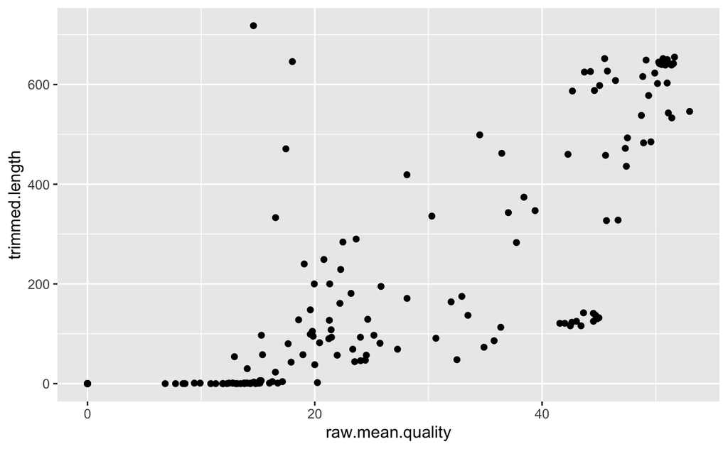

```r
ggplot(rs$read.summaries, aes(y = trimmed.length, x = raw.mean.quality)) +
      geom_point()
```

Running make.consensus.seqs:

```r
cs = make.consensus.seqs(input.folder, fwd_COI_reads, rev_COI_reads, trim = TRUE, trim.cutoff = 0.001)
```

```
[1] "Looking for .ab1 files..."
[1] "Grouping 344 files into sets by filename..."
[1] "180 of the files matched either the forward or reverse suffixes"
[1] "Grouped these into 90 sets of files"
[1] "Loading .ab1 files..."
[1] "Constructing readsets..."
[1] "Building read summaries..."
[1] "Filtering readsets with <2 reads..."
[1] "After filtering, 58 of 90 readsets remain"
[1] "Building consensus sequences..."
[1] "Successfully built 58 consensus sequences"
[1] "Summarising consensus sequences..."
```

```
no non-missing arguments to max; returning -Infno non-missing arguments to min; returning Inf
```

```
[1] "Aligning consensus sequences..."
[1] "Building tree of consensus sequences..."
```

```r
cs_default = make.consensus.seqs(input.folder, fwd_COI_reads, rev_COI_reads)
```

```
[1] "Looking for .ab1 files..."
[1] "Grouping 344 files into sets by filename..."
[1] "180 of the files matched either the forward or reverse suffixes"
[1] "Grouped these into 90 sets of files"
[1] "Loading .ab1 files..."
[1] "Constructing readsets..."
[1] "Building read summaries..."
[1] "Filtering readsets with <2 reads..."
[1] "After filtering, 43 of 90 readsets remain"
[1] "Building consensus sequences..."
[1] "Successfully built 43 consensus sequences"
[1] "Summarising consensus sequences..."
```

```
no non-missing arguments to max; returning -Infno non-missing arguments to min; returning Inf
```

```
[1] "Aligning consensus sequences..."
[1] "Building tree of consensus sequences..."
```

```r
cs_liberal_filtering = make.consensus.seqs(input.folder, fwd_COI_reads, rev_COI_reads, trim = TRUE, trim.cutoff = 0.01)
```

```
[1] "Looking for .ab1 files..."
[1] "Grouping 344 files into sets by filename..."
[1] "180 of the files matched either the forward or reverse suffixes"
[1] "Grouped these into 90 sets of files"
[1] "Loading .ab1 files..."
[1] "Constructing readsets..."
[1] "Building read summaries..."
[1] "Filtering readsets with <2 reads..."
[1] "After filtering, 67 of 90 readsets remain"
[1] "Building consensus sequences..."
[1] "Successfully built 67 consensus sequences"
[1] "Summarising consensus sequences..."
```

```
no non-missing arguments to max; returning -Infno non-missing arguments to min; returning Inf
```

```
[1] "Aligning consensus sequences..."
[1] "Building tree of consensus sequences..."
```

Compare summaries:

| file.path | folder.name | file.name | raw.length | trimmed.length | trim.start | trim.finish | raw.secondary.peaks | trimmed.secondary.peaks | raw.mean.quality | trimmed.mean.quality | raw.min.quality | trimmed.min.quality | read.included.in.readset | readset.name | read.included.in.consensus | consensus.name |
| --- | --- | --- | --- | --- | --- | --- | --- | --- | --- | --- | --- | --- | --- | --- | --- | --- |
| /Users/laherrera/OneDrive - UC Davis/Summer 2019/coral_thermotolerance/Data/abif///COI_1_LAH001_Plate_PCR_00001457_H12.ab1 | abif | COI_1_LAH001_Plate_PCR_00001457_H12.ab1 | 685 | 633 | 40 | 672 | 37 | 28 | 42.484892 | 45.64139 | 2 | 2 | TRUE | /Users/laherrera/OneDrive - UC Davis/Summer 2019/coral_thermotolerance/Data/abif///COI_1 | TRUE | /Users/laherrera/OneDrive - UC Davis/Summer 2019/coral_thermotolerance/Data/abif///COI_1 |
| /Users/laherrera/OneDrive - UC Davis/Summer 2019/coral_thermotolerance/Data/abif///COI_1_LAH002_Plate_PCR_00001457_H12.ab1 | abif | COI_1_LAH002_Plate_PCR_00001457_H12.ab1 | 640 | 357 | 124 | 480 | 474 | 271 | 13.804688 | 14.46499 | 5 | 5 | TRUE | /Users/laherrera/OneDrive - UC Davis/Summer 2019/coral_thermotolerance/Data/abif///COI_1 | TRUE | /Users/laherrera/OneDrive - UC Davis/Summer 2019/coral_thermotolerance/Data/abif///COI_1 |
| /Users/laherrera/OneDrive - UC Davis/Summer 2019/coral_thermotolerance/Data/abif///COI_10_LAH001_Plate_PCR_00001457_B02.ab1 | abif | COI_10_LAH001_Plate_PCR_00001457_B02.ab1 | 684 | 655 | 13 | 667 | 24 | 20 | 44.510204 | 45.97252 | 2 | 6 | TRUE | /Users/laherrera/OneDrive - UC Davis/Summer 2019/coral_thermotolerance/Data/abif///COI_10 | TRUE | /Users/laherrera/OneDrive - UC Davis/Summer 2019/coral_thermotolerance/Data/abif///COI_10 |
| /Users/laherrera/OneDrive - UC Davis/Summer 2019/coral_thermotolerance/Data/abif///COI_10_LAH002_Plate_PCR_00001457_B02.ab1 | abif | COI_10_LAH002_Plate_PCR_00001457_B02.ab1 | 447 | 186 | 41 | 226 | 308 | 126 | 14.799107 | 14.47312 | 4 | 5 | TRUE | /Users/laherrera/OneDrive - UC Davis/Summer 2019/coral_thermotolerance/Data/abif///COI_10 | TRUE | /Users/laherrera/OneDrive - UC Davis/Summer 2019/coral_thermotolerance/Data/abif///COI_10 |
| /Users/laherrera/OneDrive - UC Davis/Summer 2019/coral_thermotolerance/Data/abif///COI_11_LAH001_Plate_PCR_00001457_C02.ab1 | abif | COI_11_LAH001_Plate_PCR_00001457_C02.ab1 | 686 | 655 | 13 | 667 | 29 | 27 | 43.645441 | 45.29618 | 2 | 6 | TRUE | /Users/laherrera/OneDrive - UC Davis/Summer 2019/coral_thermotolerance/Data/abif///COI_11 | FALSE | NA |
| /Users/laherrera/OneDrive - UC Davis/Summer 2019/coral_thermotolerance/Data/abif///COI_11_LAH002_Plate_PCR_00001457_C02.ab1 | abif | COI_11_LAH002_Plate_PCR_00001457_C02.ab1 | 513 | 1 | 513 | 513 | 372 | 1 | 14.060429 | 41.00000 | 3 | 41 | FALSE | /Users/laherrera/OneDrive - UC Davis/Summer 2019/coral_thermotolerance/Data/abif///COI_11 | FALSE | NA |
| /Users/laherrera/OneDrive - UC Davis/Summer 2019/coral_thermotolerance/Data/abif///COI_12_LAH001_Plate_PCR_00001457_D02.ab1 | abif | COI_12_LAH001_Plate_PCR_00001457_D02.ab1 | 680 | 655 | 10 | 664 | 22 | 17 | 45.503660 | 46.87634 | 2 | 6 | TRUE | /Users/laherrera/OneDrive - UC Davis/Summer 2019/coral_thermotolerance/Data/abif///COI_12 | TRUE | /Users/laherrera/OneDrive - UC Davis/Summer 2019/coral_thermotolerance/Data/abif///COI_12 |
| /Users/laherrera/OneDrive - UC Davis/Summer 2019/coral_thermotolerance/Data/abif///COI_12_LAH002_Plate_PCR_00001457_D02.ab1 | abif | COI_12_LAH002_Plate_PCR_00001457_D02.ab1 | 359 | 118 | 100 | 217 | 256 | 87 | 14.791086 | 15.91525 | 4 | 5 | TRUE | /Users/laherrera/OneDrive - UC Davis/Summer 2019/coral_thermotolerance/Data/abif///COI_12 | TRUE | /Users/laherrera/OneDrive - UC Davis/Summer 2019/coral_thermotolerance/Data/abif///COI_12 |
| /Users/laherrera/OneDrive - UC Davis/Summer 2019/coral_thermotolerance/Data/abif///COI_13_LAH001_Plate_PCR_00001457_E02.ab1 | abif | COI_13_LAH001_Plate_PCR_00001457_E02.ab1 | 680 | 655 | 11 | 665 | 24 | 20 | 44.849195 | 46.16336 | 2 | 6 | TRUE | /Users/laherrera/OneDrive - UC Davis/Summer 2019/coral_thermotolerance/Data/abif///COI_13 | FALSE | NA |
| /Users/laherrera/OneDrive - UC Davis/Summer 2019/coral_thermotolerance/Data/abif///COI_13_LAH002_Plate_PCR_00001457_E02.ab1 | abif | COI_13_LAH002_Plate_PCR_00001457_E02.ab1 | 309 | 1 | 309 | 309 | 230 | 1 | 11.935275 | 34.00000 | 4 | 34 | FALSE | /Users/laherrera/OneDrive - UC Davis/Summer 2019/coral_thermotolerance/Data/abif///COI_13 | FALSE | NA |

[output cut: 170 more lines]

Writing FASTA files: NOTE: 8/14/2019: Need to resolve ambiguities based on the the traces of forward and reverse reads. Files generated with the word “preliminary” because ambiguities need to be resolved.

```r
write.dna(cs_liberal_filtering$consensus.sequences, file = "~/OneDrive - UC Davis/Summer 2019/coral_thermotolerance/Data/COI_liberal_consensus_sequences.fasta", format = 'fasta', nbcol = -1, colsep = "", colw = 10000000)
write.dna(cs_default$consensus.sequences, file = "~/OneDrive - UC Davis/Summer 2019/coral_thermotolerance/Data/COI_default_consensus_sequences.fasta", format = 'fasta', nbcol = -1, colsep = "", colw = 10000000)
write.dna(cs$consensus.sequences, file = "~/OneDrive - UC Davis/Summer 2019/coral_thermotolerance/Data/COI_consensus_sequences.fasta", format = 'fasta', nbcol = -1, colsep = "", colw = 10000000)
```

Resolving sequence ambiguity: Goal: Improve COI database search by resolving degerenate base calls

### Sample 23: ID’ed as Galaxea fascicularis

COI sequence matches Galaxea fascicularis with 100% identity. Other species matches include G. astreata (100%)

```r
seq.filepath.23.f = "~/OneDrive - UC Davis/Summer 2019/coral_thermotolerance/Data/1637633/COI_23_LAH001_Plate_PCR_00001457_D03.ab1"

seq.filepath.23.r = "~/OneDrive - UC Davis/Summer 2019/coral_thermotolerance/Data/1637633/COI_23_LAH002_Plate_PCR_00001457_D03.ab1"

seq.abif.23.f= read.abif(seq.filepath.23.f)
seq.abif.23.r= read.abif(seq.filepath.23.r)

seq.sanger.23.f = sangerseq(seq.abif.23.f)
seq.sanger.23.r = sangerseq(seq.abif.23.r)

sp.23.f = secondary.peaks(seq.sanger.23.f)
sp.23.r = secondary.peaks(seq.sanger.23.r)

sp.23.f$secondary.peaks
sp.23.r$secondary.peaks

sp.23.f$read
sp.23.r$read

sp.23.f = secondary.peaks(seq.sanger.23.f, output.folder = "~/OneDrive - UC Davis/Summer 2019/coral_thermotolerance/Data/chromatograms/", file.prefix = "COI_23_LAH001_Plate_PCR_00001457_D03")

sp.23.r = secondary.peaks(seq.sanger.23.r, output.folder = "~/OneDrive - UC Davis/Summer 2019/coral_thermotolerance/Data/chromatograms/", file.prefix = "COI_23_LAH002_Plate_PCR_00001457_D03")
```

## NFkB

```r
nfkb.cs = make.consensus.seqs(input.folder, fwd_NFkB_reads, rev_NFkB_reads, trim = TRUE, trim.cutoff = 0.001)
```

```
[1] "Looking for .ab1 files..."
[1] "Grouping 311 files into sets by filename..."
[1] "82 of the files matched either the forward or reverse suffixes"
[1] "Grouped these into 41 sets of files"
[1] "Loading .ab1 files..."
[1] "Constructing readsets..."
[1] "Building read summaries..."
[1] "Filtering readsets with <2 reads..."
[1] "After filtering, 32 of 41 readsets remain"
[1] "Building consensus sequences..."
[1] "Successfully built 32 consensus sequences"
[1] "Summarising consensus sequences..."
```

```
no non-missing arguments to max; returning -Infno non-missing arguments to min; returning Inf
```

```
[1] "Aligning consensus sequences..."
[1] "Building tree of consensus sequences..."
```

## Catalase

```r
cat.cs = make.consensus.seqs(input.folder, fwd_cat_reads, rev_cat_reads, trim = TRUE, trim.cutoff = 0.001)
```

```
[1] "Looking for .ab1 files..."
[1] "Grouping 311 files into sets by filename..."
[1] "82 of the files matched either the forward or reverse suffixes"
[1] "Grouped these into 41 sets of files"
[1] "Loading .ab1 files..."
[1] "Constructing readsets..."
[1] "Building read summaries..."
[1] "Filtering readsets with <2 reads..."
[1] "After filtering, 30 of 41 readsets remain"
[1] "Building consensus sequences..."
[1] "Successfully built 30 consensus sequences"
[1] "Summarising consensus sequences..."
```

```
no non-missing arguments to max; returning -Infno non-missing arguments to min; returning Inf
```

```
[1] "Aligning consensus sequences..."
[1] "Building tree of consensus sequences..."
```

```r
BrowseSeqs(cat.cs$consensus.alignment)
```